# Søvn og fysisk aktivitet

Bjornsdottir et al. (2024) Association between physical activity over a 10-year period and current insomnia symptoms, sleep duration and daytime sleepiness: a European population-based study

## Beskriv studien

- Introduksjon, problemstilling og hensikt
- Metode, utvalg, datainnsamling, variabler, kausal analyse, statistisk analyse
- Resultater
- Konklusjoner

## Introduksjon

- Søvnproblemer er assosiert med helseplager (kardiovaskulær sykdom, metabolsk syndrom, psykiske symptomer og dødelighet)
- Fysisk aktivitet er assosiert med bedre søvnkvalitet, men
- …studier har ikke undersøkt sammenhenger over tid, og sammenheng mellom forandring i fysisk aktivitet og søvn

## Hensikt

> « the aim of the present study was to assess the inter-relationship between PA, based on frequency, duration and intensity, and symptoms of insomnia, selfreported sleep durations and daytime sleepiness among middle-aged subjects from 21 centres in nine countries at two moments in time, 10 years apart, providing important longitudinal follow-up data. »

*PA: Physical Activity*

## Metode, utvalg

- Randomly selected samples from subjects aged 20–44 in order to track them for asthma, allergy and lung disease
- Participants completed a short postal questionnaire about asthma and asthma-like symptoms and, from those who responded, a random sample was selected to undergo a more detailed clinical examination.

## Metode, datainnsamling/variabler

- Helsevariabler
  - Røyking → “Current smokers”, “Former smokers”, “never smokers”.
  - BMI
- Fysisk aktivitet
  - “Participants who exercised two or more times a week, for at least 1 hour/week, were classified as physically active.”
  - Forandring i fysisk aktivitet → “persistently non-active”, “became inactive”, “became active”, “persistently active”
- Søvn
  - “Insomnia symptoms”
  - “Sleep duration”
  - “Daytime sleepiness”

## Metode, kausal analyse

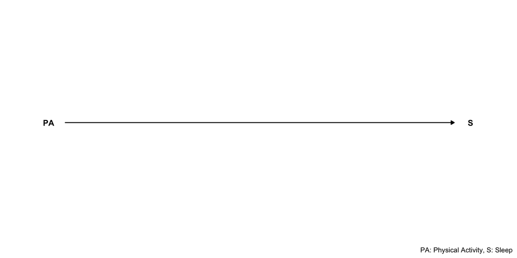

## Kausal analyse

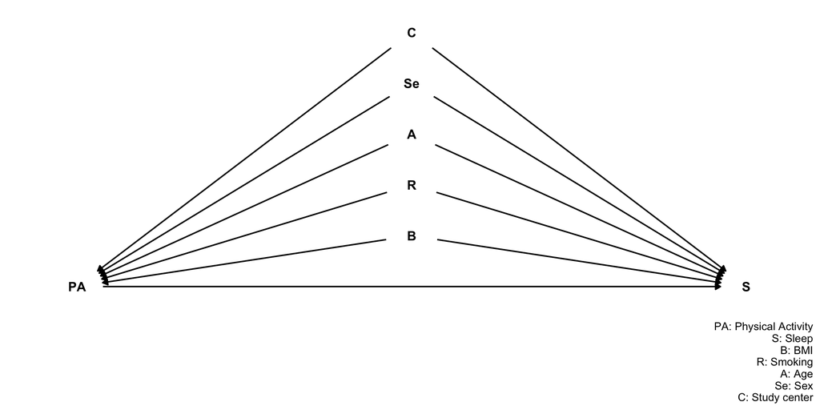

## Metode, statistisk analyse

> For bivariate analysis, the χ2 test and one-way analysis of variance were used for nominal and continuous variables. Logistic regression was used for multivariable analyses to estimate the association between PA and sleep-related outcomes

## Resultater

- Adjusted vs. unadjsuted analyses?
- Hva fant de?

## Resultater

> In unadjusted analysis, there was a significant difference in reporting difficulties initiating sleep, early morning awakenings and any insomnia symptom where those persistently active were least likely to report these symptoms. Also, persistently active subjects were the least likely to report having two or three insomnia symptoms

> After adjusting for age, sex, BMI, smoking history and study centre, this negative association remained significant for difficulties initiating sleep (OR 0.58 (0.420.77)), any insomnia symptom (OR 0.78 (0.65–0.94)) and reporting two (OR 0.60 (0.43–0.82)) and three (OR 0.63 (0.41–0.98)) insomnia symptoms

## Resultater

> In unadjusted analysis, there was a significant difference in short and long sleep durations between levels of activity. Those who were persistently active were most likely to be normal sleepers while the persistently nonactive were least likely to be in that category (70.9% vs 59.2%, respectively)

> After adjusting for age, sex, BMI, smoking history and study centre, these results remained significant for persistently active subjects. They were significantly more likely to be normal sleepers (OR 1.55 (1.29–1.87)) and significantly less likely to be short sleepers (OR 0.71 (0.58–0.85)) or long sleepers (OR 0.48 (0.28–0.80))

## Konklusjon

> The main results of this study were that participants who reported being physically active at the start and end of a 10-year follow-up period were less likely to report insomnia symptoms at the follow-up. We also found that subjects who are persistently active are more likely to sleep the recommended 6–9 hours. This association remained statistically significant after adjusting for sex, age, smoking history and BMI.